# Spotify data analysis

Joy Pham

This is my personal project to practice my newly learned skills on R. It’s less than a month since I started, though.

As you may know, we can require our personal data from Spotify. They would send you a report regarding your streaming history, your playlists, subcription and so on. To obtain that report, check this [link](https://support.spotify.com/us/article/data-rights-and-privacy-settings/).

It might take some days before you can receive the data set from Spotify. Once you got your hand on it, why not try some fun analysis?

This analysis was inspired by this [article](https://towardsdatascience.com/explore-your-activity-on-spotify-with-r-and-spotifyr-how-to-analyze-and-visualize-your-stream-dee41cb63526) by Saúl Buentello. Drop by and give him a clap!

## Set up

```r
library(readr)
library(DBI)
library(viridis)
library(lubridate)
library(tidyverse)
library(ggplot2)
library(spotifyr)
library(plotly)
library(knitr)
library("gghighlight")
library(jsonlite)
```

As you may notice, there a library called **“spotifyr”**, which was created by GitHub user “charlie86”. This library will allow you to obtain more details using Spotify API. You can find more examples about what you can do with “spotifyr” in this repository: spotifyr

Now, we use functions from our **‘jsonlite’** library to convert our Spotify data file into csv.

```r
## Convert
stream00 <- fromJSON("Path to your file", flatten = TRUE)
```

Since I have 2 files in my data, I have to merge them into one full file before starting my analysis.

```r
## Merge 2 file into 1 complete file
my_spotify <- rbind(stream00, stream01)
```

Let’s take a glance at our data set.

```r
str(my_spotify)
```

```
## 'data.frame':    19275 obs. of  4 variables:
##  $ endTime   : chr  "2020-08-07 14:18" "2020-09-06 01:47" "2020-09-06 02:06" "2020-09-06 02:07" ...
##  $ artistName: chr  "Taylor Swift" "ONE OK ROCK" "ONE OK ROCK" "The Weeknd" ...
##  $ trackName : chr  "Everything Has Changed" "We Are" "We Are" "Can't Feel My Face" ...
##  $ msPlayed  : int  148331 211323 44078 85440 4392 195924 205133 2169 117165 202586 ...
```

Let’s dig in!

## How many hours per week did you spend on Spotify?

I guess this is one of the first questions popped in your head once you get your Spotify data.

```r
# Adding date and hour
spotify_data <- my_spotify %>%
  as_tibble() %>%
  mutate_at("endTime", ymd_hm) %>%
  mutate(endTime = endTime - hours(6)) %>%
  mutate(date = floor_date(endTime, "day") %>% as_date, seconds = msPlayed / 1000, minutes = seconds / 60)
```

With date, minutes and seconds added, you now can make your first plot to see your activity per week.

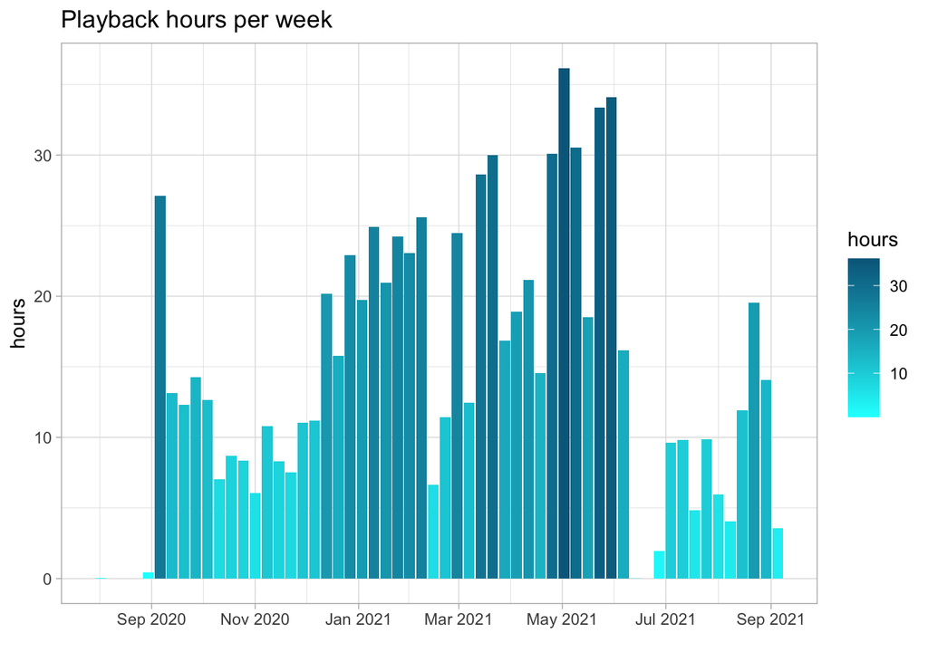

```r
# Playback hours per week
stream_in_hours <- spotify_data %>%
  group_by(date = floor_date(date, "week")) %>%
  summarize(hours = sum(minutes)/60) %>%
  arrange(date) %>%
  ggplot(aes(x = date, y = hours)) +
  geom_col(aes(fill = hours)) +
  scale_x_date(date_labels = "%b %Y", date_breaks= "2 month") +
  scale_fill_gradient(low = "cyan", high = "deepskyblue4") +
  labs(title = "Playback hours per week") +
  xlab("") +
  theme_light()

stream_in_hours
```

## Which artist did you spend the most time listening to?

You can easily find the answer using the **(“gghighlight”)** library by filtering your data with specific **artistName**.

In my case, I believed I did listen to Taylor Swift and Ed Sheeran a lot.

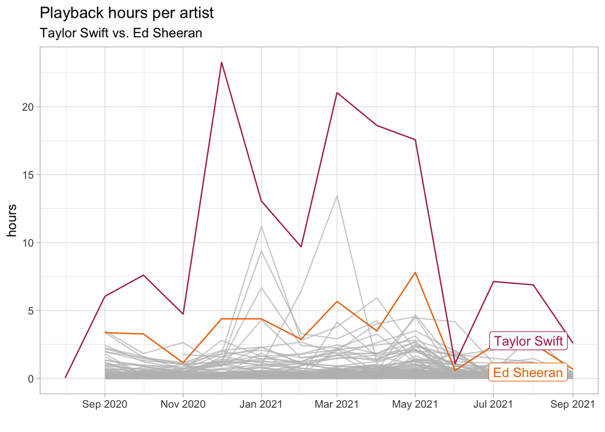

```r
## Playback per specific artists: Taylor Swift and Ed Sheeran
taylor_ed <- spotify_data %>%
  group_by(artistName, date = floor_date(date, "month")) %>%
  summarize(hours = sum(minutes)/60) %>%
  ggplot(aes(x= date, y= hours, group = artistName, color = artistName)) +
  geom_line() +
  gghighlight(artistName == "Taylor Swift" ||
              artistName == "Ed Sheeran") +
  scale_x_date(date_labels = "%b %Y", date_breaks = "2 month") +
  scale_color_manual(values = c("darkorange2", "maroon")) +
  labs(title = "Playback hours per artist", subtitle = "Taylor Swift vs. Ed Sheeran") +
  xlab("") +
  theme_light()

taylor_ed
```

Well, it seems that Taylor did dominate my Spotify. Is it make me a Swiftie?

### JPop

##### Most listened to artists

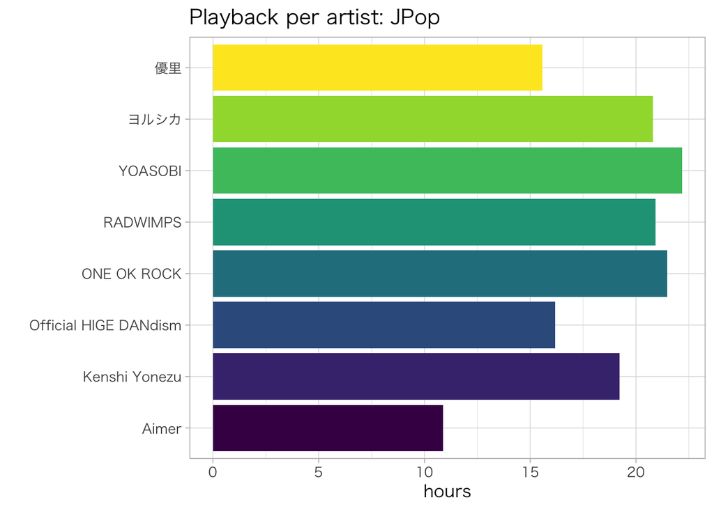

```r
# Playback per specific artists: J-Pop
jpop_artist <- spotify_data %>%
  group_by(artistName, date = floor_date(date, "hour")) %>%
  mutate(artistName = iconv(artistName, to = "UTF-8")) %>%
  filter(artistName == "YOASOBI" ||
         artistName == "Official HIGE DANdism" ||
         artistName == "ヨルシカ" ||
         artistName == "Kenshi Yonezu" ||
         artistName == "優里" ||
         artistName == "ONE OK ROCK" ||
         artistName == "Aimer" ||
         artistName == "RADWIMPS") %>%
  summarize(hours = sum(minutes)/60) %>%
  ggplot(aes(x= artistName, y = hours)) +
  geom_col(aes(fill = artistName))+
  scale_fill_viridis(discrete = TRUE,guide = FALSE, option="D") +
  labs(title = "Playback per artist: JPop") +
  theme_light(base_size=12, base_family="HiraKakuProN-W3") +
  xlab("") +
  coord_flip()

jpop_artist
```

##### Songs per artist

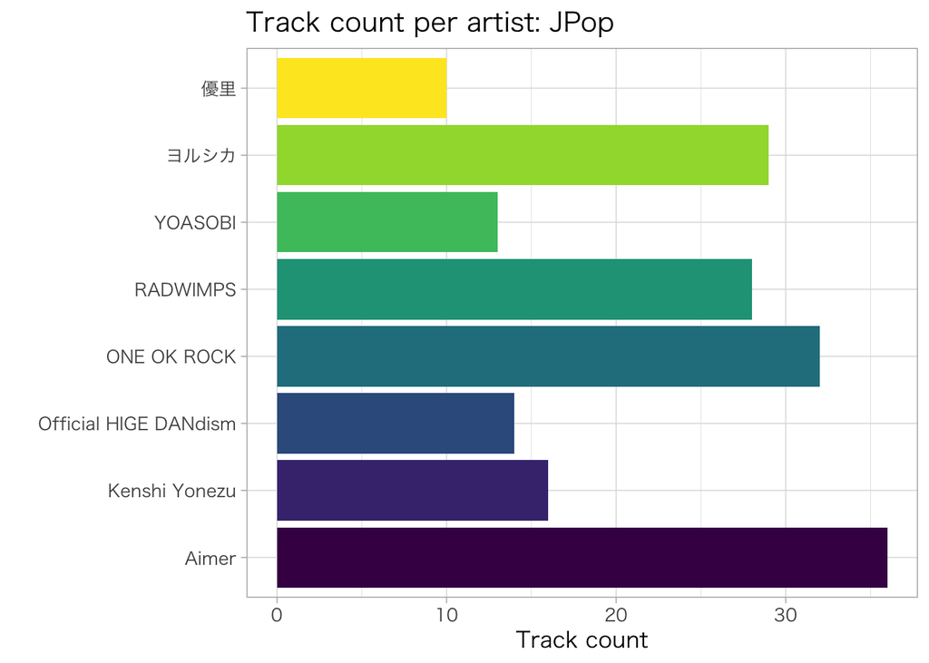

```r
# Track count per artist: JPop
jpop_artist_count <- spotify_data %>%
  group_by(artistName, trackName) %>%
  mutate(artistName = iconv(artistName, to = "UTF-8")) %>%
  filter(artistName == "YOASOBI" ||
         artistName == "Official HIGE DANdism" ||
         artistName == "ヨルシカ" ||
         artistName == "Kenshi Yonezu" ||
         artistName == "優里" ||
         artistName == "ONE OK ROCK" ||
         artistName == "Aimer" ||
         artistName == "RADWIMPS") %>%
  summarize(trackCount = n_distinct(trackName)) %>%
  ggplot(aes(x= artistName, y = trackCount)) +
  geom_col(aes(fill = artistName))+
  scale_fill_viridis(discrete = TRUE,guide = FALSE, option="D") +
  labs(title = "Track count per artist: JPop") +
  theme_light(base_size=12, base_family="HiraKakuProN-W3") +
  xlab("") +
  ylab("Track count") +
  coord_flip()

jpop_artist_count
```

There are a lot of Aimer’s though I mostly skimmed through them. ヨルシカ is another story, I love this band and the deep of their lyrics, specially *suis-san* incredible voice. If you want to bang your head, try ONE OK ROCK.

## Which artist that you listened to most?

Since I’m not sure what minimum playing hours should be, I will arrange the playing time in descending order and pick the top 15 artists. However, you can easily set a minimum threshold by adding a filter.

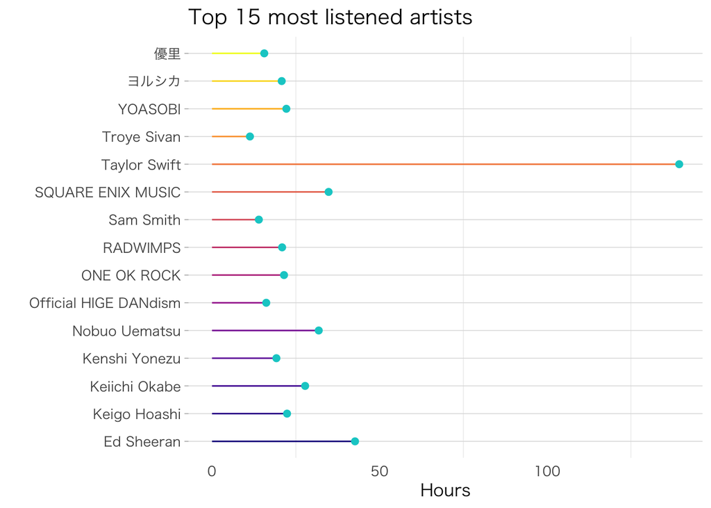

```r
most_listened <- spotify_data %>%
  group_by(artistName) %>%
  mutate(artistName = iconv(artistName, to = "UTF-8")) %>%
  summarize(listenedHours = sum(minutes)/60) %>%
  arrange(desc(listenedHours)) %>%
  slice(1:15) %>%
  ggplot(aes(x = artistName, y = listenedHours,
             color = artistName)) +
  geom_segment(aes(x= artistName, xend= artistName,
                   y= 0, yend = listenedHours)) +
  geom_point(size = 2, color = "cyan3") +
  scale_color_viridis(discrete = TRUE, guide = FALSE, option="C") +
  theme_light(base_size=12, base_family="HiraKakuProN-W3") +
  theme (
    panel.grid.major.x = element_blank(),
    panel.border = element_blank(),
    axis.ticks.x = element_blank(),
  ) +
  labs(title = "Top 15 most listened artists") +
  xlab("") +
  ylab("Hours") +
  coord_flip()

most_listened
```

Oh, it’s Taylor, again! She definitely rules my Spotify! I just realize that I listened to a lot of game soundtracks. Most of them are from Final Fantasy franchises and NieR series, both belong to Square Enix.

## And, who has the most songs?

Actually, I can guess the result already. But, let’s check!

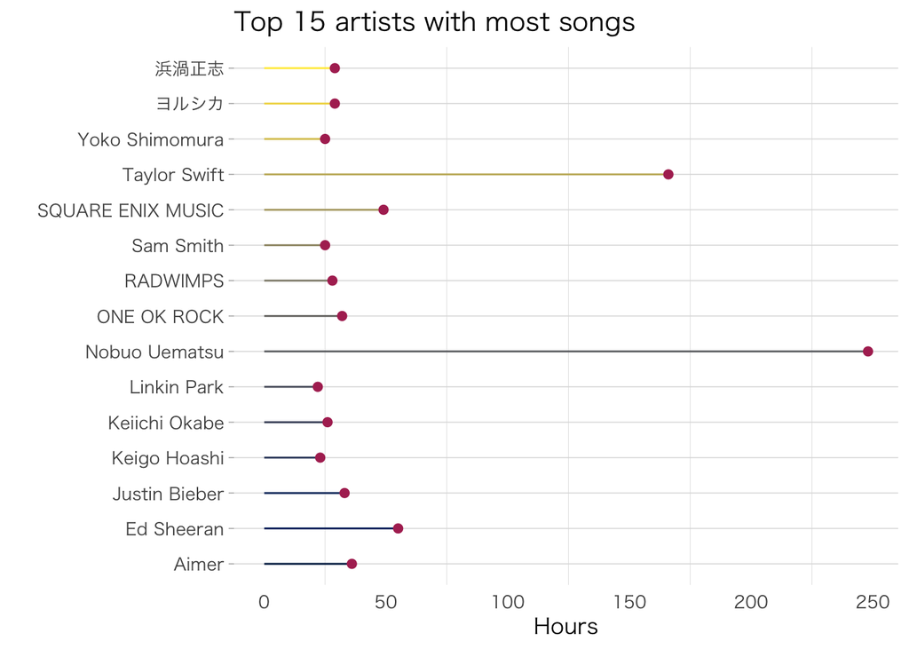

```r
most_songs <- spotify_data %>%
  group_by(artistName) %>%
  mutate(artistName, iconv(artistName, to = "UTF-8")) %>%
  summarize(total_songs = n_distinct(trackName)) %>%
  arrange(desc(total_songs)) %>%
  slice(1:15) %>%
  ggplot(aes(x= artistName, y= total_songs, color= artistName)) +
  geom_segment(aes(x= artistName, xend= artistName, y= 0, yend= total_songs)) +
  geom_point(size= 2, color= "maroon") +
  scale_color_viridis(discrete = TRUE, guide = FALSE, option="E") +
  theme_light(base_size=12, base_family="HiraKakuProN-W3") +
  theme (
    panel.grid.major.x = element_blank(),
    panel.border = element_blank(),
    axis.ticks.x = element_blank(),
  ) +
  labs(title = "Top 15 artists with most songs") +
  xlab("") +
  ylab("Hours") +
  coord_flip()

most_songs
```

Finally, there’s a battle that Taylor would lose. Roughly 250 songs from Nobuo Uematsu! Yup, that’s Final Fantasy franchises.

## You can also check if times spent on an artist has any relationship with the number of song from him/her.

As you may know, to check whether 2 variables are related to each other, we would use scatterplot.

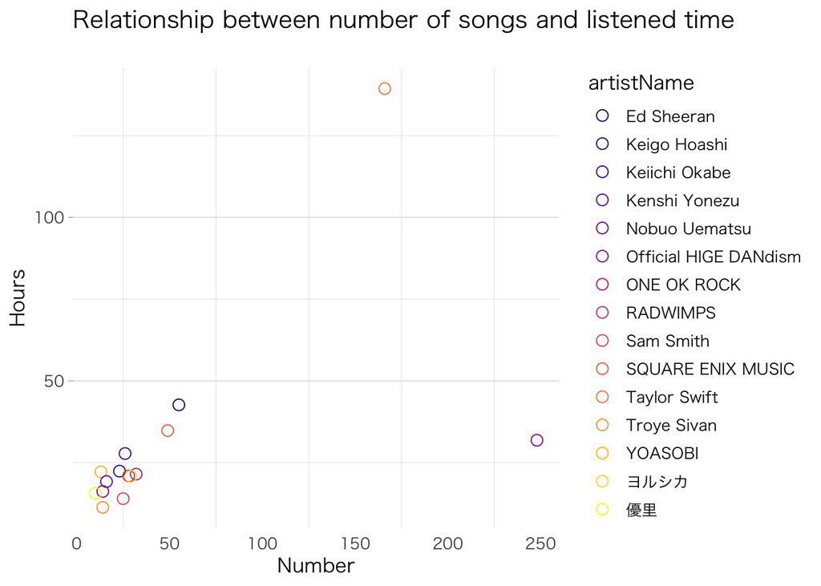

```r
# Listened time vs. number of songs
listenedTimes_songs <- spotify_data %>%
  group_by(artistName) %>%
  mutate(artistName = iconv(artistName, to = "UTF-8")) %>%
  summarize(listenedHours = sum(minutes)/60, total_songs= n_distinct(trackName)) %>%
  arrange(desc(listenedHours, total_songs)) %>%
  slice(1:15) %>%
  ggplot(aes(x = total_songs, y = listenedHours,color = artistName)) +
  geom_point(size = 3, shape = 21 ) +
  scale_color_viridis(discrete = TRUE, option="C") +
  theme_light(base_size=12, base_family="HiraKakuProN-W3") +
  theme (
    panel.grid.major.x = element_blank(),
    panel.border = element_blank(),
    axis.ticks.x = element_blank(),
  ) +
  labs(title = "Relationship between number of songs and listened time
       ") +
  xlab("Number") +
  ylab("Hours")

listenedTimes_songs
```

So, it seems that the number of songs has nothing to do with the listened time. Still, it’s funny to see Taylor’s lonely ring on the top of the graph.

## Most listened songs

I guess you would wonder which songs you got hooked on the most. Let’s check our top 15 most listened songs.

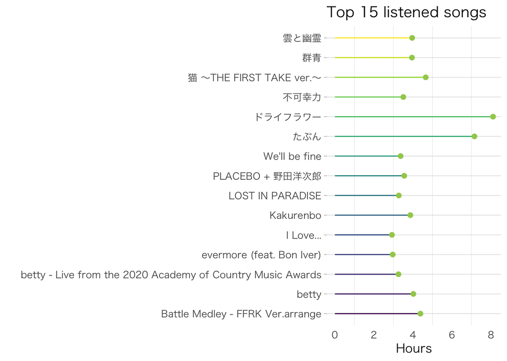

```r
# Top 15 most listened songs
top_songs <- spotify_data %>%
  group_by(trackName) %>%
  summarize(hours= sum(minutes)/60) %>%
  arrange(desc(hours)) %>%
  slice(1:15) %>%
  ggplot(aes(x= trackName, y= hours, color= trackName)) +
  geom_segment(aes(x= trackName, xend= trackName, y= 0, yend= hours)) +
  geom_point(size= 2, color= "darkolivegreen3") +
  scale_color_viridis(discrete = TRUE, guide = FALSE, option="D") +
  theme_light(base_size=12, base_family="HiraKakuProN-W3") +
  theme (
    panel.grid.major.x = element_blank(),
    panel.border = element_blank(),
    axis.ticks.x = element_blank(),
  ) +
  labs(title = "Top 15 listened songs") +
  xlab("") +
  ylab("Hours") +
  coord_flip()

top_songs
```

Though Taylor is my most listened artist, 11/15 of my most listening songs were Japanese, with ドライフラワー(Dried Flower) by 優里(Yuuri) and たぶん(Probably) by YOASOBI outweighed other songs.

## During the day, which hours you spent on Spotify most?

We’ll make a plot with total hours to have an overall look at which part of the day you got hooked on Spotify.

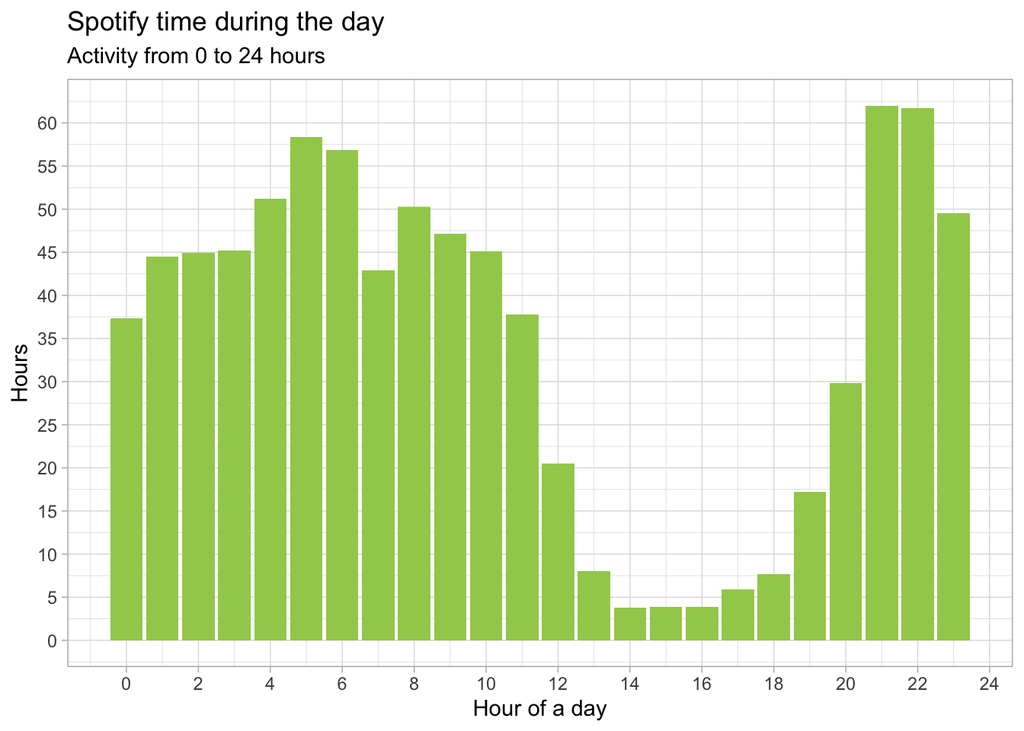

```r
# Playback hour
dayHour <- spotify_data %>%
  group_by(date, hour = hour(endTime), weekday = wday(date, label = TRUE)) %>%
  summarize(hoursListened = sum(minutes)/60)

dayHour %>%
  ggplot(aes(x= hour, y= hoursListened, group= date)) +
  geom_col(fill = "darkolivegreen3") +
  scale_fill_brewer(palette = 3) +
  scale_x_continuous(breaks = seq(0, 24, 2)) +
  scale_y_continuous(breaks = seq(0, 60, 5)) +
  labs(title = "Spotify time during the day", subtitle = "Activity from 0 to 24 hours") +
  xlab("Hour of a day") +
  ylab("Hours") +
  theme_light()
```

Oops, what a surprise! I never think I spent most of my time on Spotify during sleeping hours. It might be when I had to work on night shifts but still, this is quite a shock to see. In brief, it’s obvious that I used Spotify all day.

## During the week, what day you listened to Spotify most?

You already have a plot of your listening hours during the day, but how about during the week? Do you spend most of your Spotify time on weekdays or weekends? Let’s try it with a heatmap.

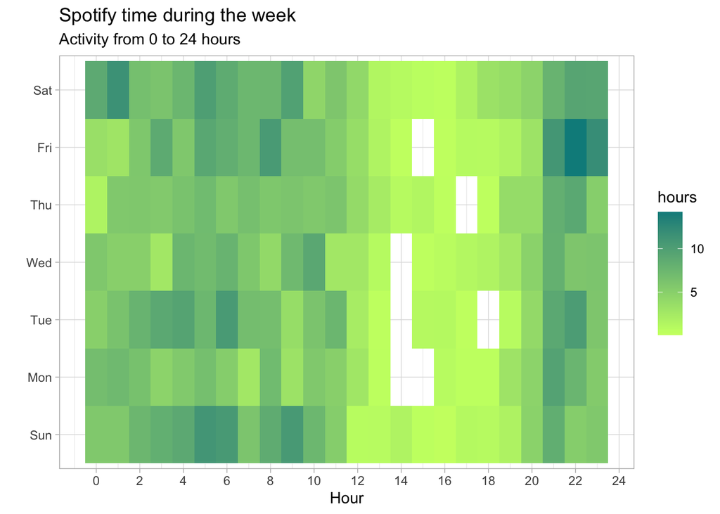

```r
# Playback activity during the week
dayHour %>%
  group_by(weekday, hour) %>%
  summarize(hours = sum(hoursListened)) %>%
  ggplot(aes(x= hour, y= weekday, fill= hours)) +
  geom_tile() +
  scale_x_continuous(breaks= seq(0, 24, 2)) +
  scale_fill_gradient(low= "darkolivegreen1", high= "cyan4") +
  labs(title= "Spotify time during the week", subtitle= "Activity from 0 to 24 hours",
       x= "Hour", y= "") +
  theme_light()
```

As I almost used Spotify non-stop, my time on the app during the week also reflects the same story though I’m sure it’s not healthy at all.

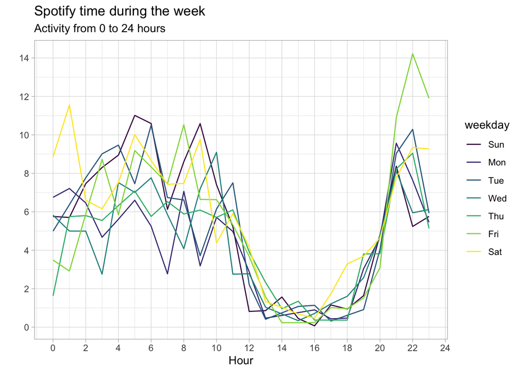

```r
weekHour <- dayHour %>%
  group_by(weekday, hour) %>%
  summarize(hours = sum(hoursListened)) %>%
  ggplot(aes(x= hour, y= hours, color= weekday)) +
  geom_line() +
  scale_color_viridis(discrete= TRUE, option= "D") +
  scale_x_continuous(breaks= seq(0, 24, 2)) +
  scale_y_continuous(breaks= seq(0, 15, 2)) +
  scale_fill_gradient(low= "darkolivegreen1", high= "cyan4") +
  labs(title= "Spotify time during the week", subtitle= "Activity from 0 to 24 hours",
       x= "Hour", y= "") +
  theme_light()

weekHour
```

Using a line plot, it can be seen that I spent a bit more time with Spotify on Friday around 22 o’clock than on other days. And, in my unhealthy listening pattern, it looks like Monday is my least favorite day.

# It’s time to try Spotifyr package

Spotify provided you your listening data. Great! But did you know that they also have an enormous amount of info such as popularity, energy, valence, how “danceable” a song is, as well as which album it belongs to?

## Set up

First, set up your Spotify Developer account [here](https://developer.spotify.com/dashboard/) which actually means logging into your current Spotify account. This allows you to make a connection with **Spotify API** and will grant you your `Client Id` and `Client Secret`. In other words, you will use this info to pull your access token into R.

Once you logged in, Spotify will get you to your dashboard. Next, click `Create an app`, fill in your app name and description to start your project. After creating your app, you would see your `Client Id` and `Client Secret`.

According to the author of `spotifyr`, your Spotify Developer application needs to have a callback url. You can set this to whatever you want that will work with your application, but a good default option is `http://localhost:1410/`. For more information on authorization, visit Spotify [Authorization Guide](https://developer.spotify.com/documentation/general/guides/authorization-guide/).

Click on **Edit Setting** and input the callback url into `Redirect URIs` field. Click Save, and you’re all set! The last thing you have to do is to authorize your R analysis with Spotify.

```r
Sys.setenv(SPOTIFY_CLIENT_ID = 'xxxxxxxxxxxxxxxxxxxxx')
Sys.setenv(SPOTIFY_CLIENT_SECRET = 'xxxxxxxxxxxxxxxxxxxxx')

access_token <- get_spotify_access_token()
```

## What are your favorite artists?

The data set I’m working with is quite old and some of the information might not be correct. So I’ll use `spotifyr` to check again since this package is able to pull data from Spotify in real-time. Also note that the code might take some time to process depending on your connection. Execute `?spotify` or visit the author GitHub in the above link for more information regarding this package.

```r
#Top recent favorite artists
top_artists_real <- get_my_top_artists_or_tracks(type = 'artists',
                             time_range = 'long_term',
                             limit = 15)
top_artists_real %>%
  select(name, genres, popularity, "followers.total") %>%
  rowwise %>%
  mutate(genres = paste(.data$genres, collapse = ', ')) %>%
  ungroup
```

```
## # A tibble: 15 × 4
##    name                  genres                       popularity followers.total
##    <chr>                 <chr>                             <int>           <int>
##  1 Taylor Swift          pop                                  94        43609920
##  2 Nobuo Uematsu         anime score, chiptune, fina…         64          234735
##  3 RADWIMPS              j-pop, j-rock, japanese emo…         71         2543062
##  4 Ed Sheeran            pop, uk pop                          94        85607942
##  5 ONE OK ROCK           j-pop, j-rock, japanese emo…         71         4058380
##  6 ヨルシカ              j-pop                                68         1414869
##  7 Official HIGE DANdism anime, anime rock, j-pop             75         3897510
##  8 Sam Smith             dance pop, pop, uk pop               86        17594846
##  9 Kenshi Yonezu         anime, j-pop                         72         3250879
## 10 Maroon 5              pop, pop rock                        88        33139149
## 11 Aimer                 anime, anime rock, j-pixie,…         67         1547041
## 12 SQUARE ENIX MUSIC     anime score, final fantasy,…         53           51320
## 13 Troye Sivan           australian pop, dance pop, …         80         6009496
## 14 Linkin Park           alternative metal, nu metal…         85        20065691
## 15 Christopher           danish pop                           63          219595
```

As you can see from the code, `time_range` was set to `long_term` for I wanted to get the overall result since I first started using the app. However, you can set it either to `short_term` or `medium_term` as well. According to the above table, 6 out of my 10 favorite artists recently are Japanese. The different results between this data and my report from Spotify are due to the time it was recorded. I’ve been using Spotify for more than 3 years but the report I received was only recorded data from July 2020 to September 2021. Hence, the report merely reflected my recent activities while using the app.

## What are your favorite tracks?

For the result of my recent favorite artists is a lot different from my Spotify data, I want to check if my most listening tracks are similar to the old data set.

```r
#Top recent favorite songs
top_songs_real <- get_my_top_artists_or_tracks(type = 'tracks',
                             time_range = 'long_term',
                             limit = 15)

top_songs_real %>%
  mutate(
        artist.name = map_chr(artists, function(x) x$name[1])
        ) %>%
    select(name, artist.name)
```

```
##                                           name           artist.name
## 1                               ドライフラワー                  優里
## 2                    Pretender - Acoustic Ver. Official HIGE DANdism
## 3                     Death By A Thousand Cuts          Taylor Swift
## 4  Only The Young - Featured in Miss Americana          Taylor Swift
## 5                    Strawberries & Cigarettes           Troye Sivan
## 6                                       紅蓮華                  LiSA
## 7                                        Style          Taylor Swift
## 8                              Cornelia Street          Taylor Swift
## 9    Is There Still Anything That Love Can Do?              RADWIMPS
## 10                                      たぶん               YOASOBI
## 11                                  The Archer          Taylor Swift
## 12                        PLACEBO + 野田洋次郎         Kenshi Yonezu
## 13                                       Lover          Taylor Swift
## 14                               from the edge       FictionJunction
## 15                                    万歳千唱              RADWIMPS
```

The list is far different from my Spotify record since it includes my entire listening history. And, 6 out of 15 songs belong to Taylor Swift.

## What are the most popular tracks in your liked songs/ playlist?

As `spotifyr` can pull the popularity of a song, we can do an analysis to see what are the most popular tracks on your liked songs or a particular playlist. The popularity of a song is measured on the 0-100 scale, with 100 as a super hit. Each of your playlists has its own unique id which you have to use Spotify web play to obtain. Or, you can use `get_user_playlists` function to obtain the id of your playlists.

**Note**: There is no playlist id for *Liked songs* but we can work around by selecting all tracks in your “Liked songs” then drag them to a new and empty playlist.

```r
user_id <- 'jp.joy.7'

playlists <- get_user_playlists(user_id,
                                limit = 20,
                                offset = 0)
```

Next, we’ll pull the tracks data from a particular playlist using `get_playlist_audio_features` function. In my case, it’s my *Loved songs* playlist, an alias of my liked songs.

```r
username <- 'jp.joy.7'
playlist_uris <- '5fdGNZ9JWJLAT3ADDvA4Nu'

likedSongs <- get_playlist_audio_features(username, playlist_uris)
```

Take your time to analyze the result ’cause you’ll be surprised by the vast information of this data set. As I have 548 tracks and a total of 61 variables, there are lots of things I can do.

Once you’ve done, let’s get back to our initial question *What are the most popular tracks in your liked songs/ playlist?* using `track.popularity` variable. I guess songs with popularity over 80 are pretty much top hits, right?

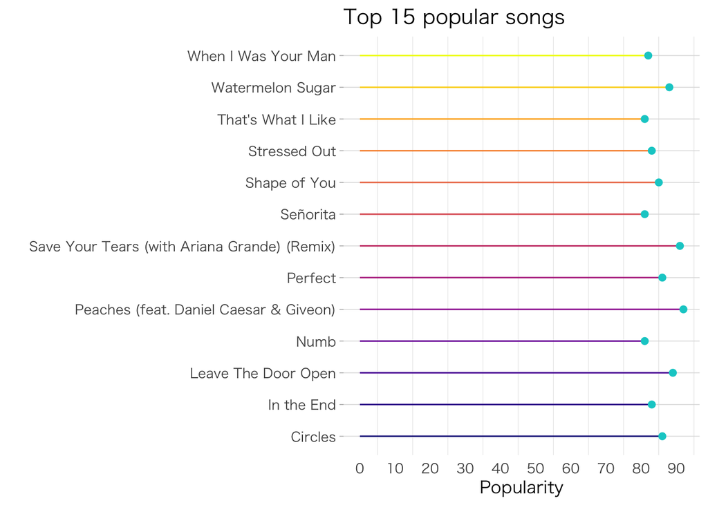

```r
# Top 15 popular songs
likedSongs %>%
  group_by(track.name) %>%
  filter(track.popularity > 80) %>%
  ggplot(aes(x = track.name, y= track.popularity, color= track.name)) +
  geom_segment(aes(x= track.name, xend= track.name, y= 0, yend= track.popularity )) +
  geom_point(size= 2, color= "cyan3") +
  scale_y_continuous(breaks= seq(0, 100, 10)) +
  scale_color_viridis(discrete = TRUE, guide = FALSE, option="C") +
  theme_light(base_size=12, base_family="HiraKakuProN-W3") +
  theme (
    panel.grid.major.x = element_blank(),
    panel.border = element_blank(),
    axis.ticks.x = element_blank(),
  ) +
  labs(title = "Top 15 popular songs") +
  xlab("") +
  ylab("Popularity") +
  coord_flip()
```

Well, none of them belongs to Taylor Swift. ;P

## What your does you taste of music tell about your personality?

I believe that one’s taste in music reflects his/ her personality. Since our `likedSongs` data has some interesting variables such as *valence* and *energy*, I’m curious what my tracks tell about me.

Here is the definition from Spotify regarding these 2 variables:

*`valence`: *A measure from 0.0 to 1.0 describing the musical positiveness conveyed by a track. Tracks with high valence sound more positive (e.g. happy, cheerful, euphoric), while tracks with low valence sound more negative (e.g. sad, depressed, angry).*

*`energy`: *Energy is a measure from 0.0 to 1.0 and represents a perceptual measure of intensity and activity. Typically, energetic tracks feel fast, loud, and noisy. For example, death metal has high energy, while a Bach prelude scores low on the scale. Perceptual features contributing to this attribute include dynamic range, perceived loudness, timbre, onset rate, and general entropy.*

You can check other variables [here](https://developer.spotify.com/documentation/web-api/reference/#endpoint-get-several-audio-features)

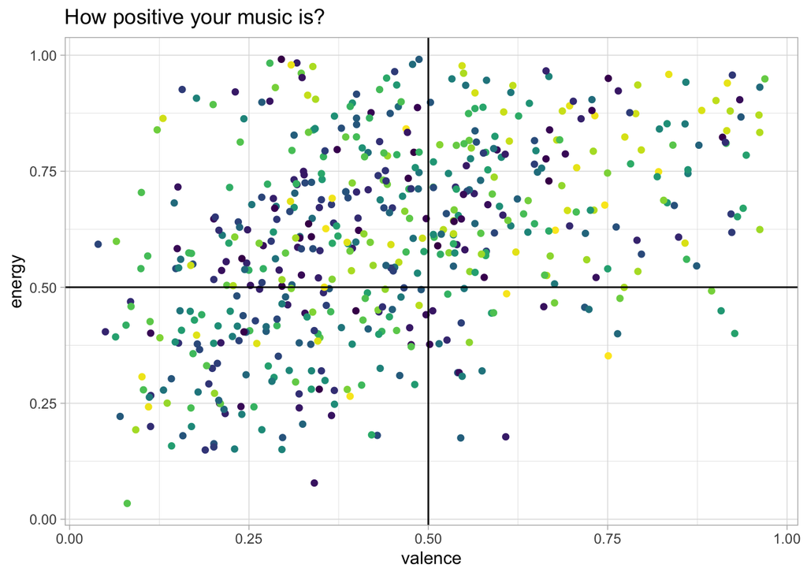

```r
# Energy and valence, liked songs
likedSongs %>%
  ggplot(aes(x= valence, y= energy, color= track.name)) +
  geom_jitter(show.legend = FALSE) +
  scale_color_viridis(discrete= TRUE, option="D") +
  geom_vline(xintercept = 0.5) +
  geom_hline(yintercept = 0.5) +
  scale_x_continuous(breaks= seq(0, 1, 0.25)) +
  scale_y_continuous(breaks= seq(0, 1, 0.25)) +
  labs(title= "How positive your music is?") +
  theme_light()
```

As seen from the plot, most of my favorite songs are on the left side, which means they are sad, depressed, or angry. However, many of those solemn tracks have high energy which can be interpreted as fast, loud, and noisy. Yet, there are still many tracks on the upper right, which represents the ‘happy valley’. In brief, my taste in music tells me that I’m quite a negative person. Well, I’m not so sure about it anyway.

## How about your workout playlist?

I think many of us would have a workout playlist to push ourselves when sweating out. Mine is quite a sassy, naughty, and fun, *Workout Playlist for hot girls 👅* by a Spotify user named *Stormy Chocada*. Let’s check how energetic and ‘danceable’ it is.

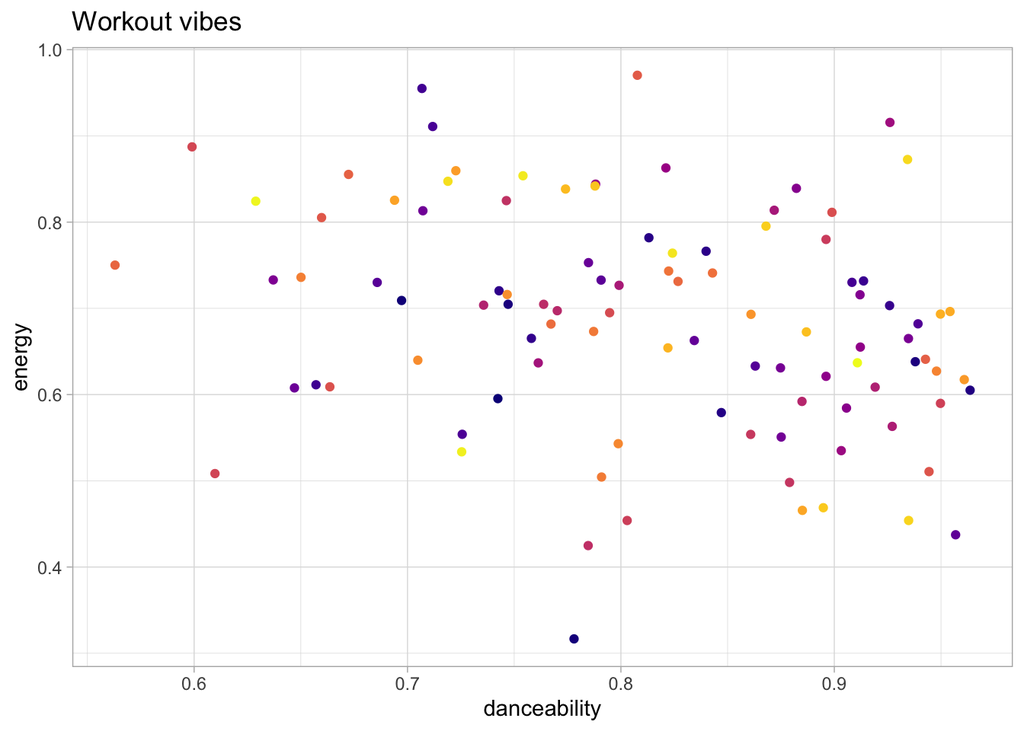

```r
# Hot girls workout
username = "jp.joy.7"
playlist_uris ="3rMa2dmPtINY46bimugyrO"

hotGirls <- get_playlist_audio_features(username, playlist_uris)

hotGirls %>%
  ggplot(aes(x= danceability, y= energy, color= track.name)) +
  geom_jitter(show.legend= FALSE) +
  scale_color_viridis(discrete= TRUE, option="C") +
  labs(title= "Workout vibes") +
  theme_light()
```

Just as my guess, those tracks are indeed very ‘danceable’ with high energy. Who could possibly workout on slow and sad BMG? At least, that’s not my case.

So, this pretty much wraps up my Spotify personal data analysis. With the huge features and vast information by using the `spotifyr` package, I’m now thinking of many projects I would do in the future. Bye for now!